# DATA 607: Document Classification; Week 10

Walt Wells, Fall 2016

# Abstract

For this project we will ingest and prepare a spam/ham dataset then build and evaluate classifer models that, given a new email, will determine whether it is spam or ham.

# Environment Prep

```r
if (!require('stringr')) install.packages('stringr')
if (!require('tm')) install.packages('tm')
if (!require('SnowballC')) install.packages('SnowballC')
if (!require('RTextTools')) install.packages('RTextTools')
if (!require('caret')) install.packages('caret')
```

# Data Source

- We are will use the [Apache SpamAssassin public email corpus](https://spamassassin.apache.org/publiccorpus/).
- More information on the dataset can be found at: https://spamassassin.apache.org/publiccorpus/readme.html
- Note - we manually removed ‘cmd’ files that were found in some of these directories.

# Data Ingestion

Compressed files from the public corpus have been downloaded and uncompressed in an “SData” directory. We will use the all the most current hard and easy spam/ham files to train and test our models.

## Review: Clean 1

```r
tmp <- readLines("SData/spam/0001.bfc8d64d12b325ff385cca8d07b84288")
tmp <- str_c(tmp, collapse = "")
tmp <- str_replace_all(tmp, pattern="<.*?>", replacement = " ")
tmp <- str_replace_all(tmp, pattern="\\=", replacement = "")
tmp
```

```
## [1] "From 12a1mailbot1@web.de  Thu Aug 22 13:17:22 2002Return-Path:  Delivered-To: zzzz@localhost.example.comReceived: from localhost (localhost [127.0.0.1])\tby phobos.labs.example.com (Postfix) with ESMTP id 136B943C32\tfor  ; Thu, 22 Aug 2002 08:17:21 -0400 (EDT)Received: from mail.webnote.net…
```

```r
tmpcorp <- Corpus(VectorSource(tmp))
meta(tmpcorp, "class") <- "spam"

# recall meta
meta(tmpcorp, "class")
```

```
##   class
## 1  spam
```

## Function: Build Corpus

```r
buildcorpus <- function(dir, class) {
    filelist <- list.files(dir)
    for (i in 1:length(filelist)){
        path <- paste0(dir, filelist[i])
        tmp <- readLines(path)
        tmp <- str_c(tmp, collapse = "")
        tmp <- str_replace_all(tmp, pattern="<.*?>", replacement = " ")
        tmp <- str_replace_all(tmp, pattern="\\=", replacement = "")

        if (!exists("corp")) {
            corp <- Corpus(VectorSource(tmp))
        } else {
            corp <- c(corp, Corpus(VectorSource(tmp)))
        }
        meta(corp[[i]], "class") <- class
    }
    corp
}

allcorp <- c(buildcorpus("SData/spam/", "spam"),
             buildcorpus("SData/spam_2/", "spam"),
             buildcorpus("SData/easy_ham/", "ham"),
             buildcorpus("SData/easy_ham_2/", "ham"),
             buildcorpus("SData/hard_ham/", "ham"))
```

# Corpus Clean

```r
# clean and prep for tf
cleancorp <- tm_map(allcorp, removeWords, stopwords("english"))
cleancorp <- tm_map(cleancorp, stripWhitespace)
cleancorp <- tm_map(cleancorp, stemDocument, language="en")
```

## Review: Clean 1 + Clean 2

```r
cleancorp[[1]][[1]]
```

```
## [1] "From 12a1mailbot1@web.d Thu Aug 22 13:17:22 2002Return-Path: Delivered-To: zzzz@localhost.example.comReceived: localhost (localhost [127.0.0.1]) phobos.labs.example.com (Postfix) ESMTP id 136B943C32 ; Thu, 22 Aug 2002 08:17:21 -0400 (EDT)Received: mail.webnote.net [193.120.211.219] localhost…
```

```r
# randomize for training / testing
cleancorp <- sample(cleancorp)
```

## Review: Spam / Ham

```r
meta_list <- factor(unlist(meta(cleancorp, "class")))
table(meta_list)
```

```
## meta_list
##  ham spam
## 4150 1896
```

```r
spamtotal <- length(which(meta_list == "spam"))
hamtotal <- length(which(meta_list == "ham"))
sratio <- round(spamtotal / (spamtotal + hamtotal), 4)
```

We calculate the ratio of spam to ham in the entire corpus to be 0.3136.

# Term Document Matrix

```r
dtm <- DocumentTermMatrix(cleancorp)
# only look at terms that appear in at least 20 of the emails
dtm <- removeSparseTerms(dtm, 1-(20/length(cleancorp)))

# preview sparsity
dtm
```

```
## <<DocumentTermMatrix (documents: 6046, terms: 5517)>>
## Non-/sparse entries: 756865/32598917
## Sparsity           : 98%
## Maximal term length: 133
## Weighting          : term frequency (tf)
```

# Modeling w/ RTextTools

For this classification task, we will train, test and compare 4 models built into the RTextTools package - Support Vector Machines, Tree, Lasso and Elastic-Net Generalized Linear Model, and Maximum Entropy.

Because of our approach to data organization, it is not trivial to implment the Naive Bayes method, which is not offered in the RTextTools package.

## Make Container

```r
# split data for train/test
N <- length(meta_list)
trainpartition <- round(.75 * N)

# make container for RTextTools
container <- create_container(
    dtm,
    labels=meta_list,
    trainSize=1:trainpartition,
    testSize=trainpartition:N,
    virgin=FALSE
)
```

## Train Models

```r
svm_model <- train_model(container, "SVM")
tree_model <- train_model(container, "TREE")
glm_model <- train_model(container, "GLMNET")
maxent_model <- train_model(container, "MAXENT")
```

## Test Models

```r
svm_out <- classify_model(container, svm_model)
tree_out <- classify_model(container, tree_model)
glm_out <- classify_model(container, glm_model)
maxent_out <- classify_model(container, maxent_model)
```

# Evaluate Performance

```r
labels_out <- data.frame(
    correct_label = meta_list[trainpartition:N],
    svm = as.character(svm_out[,1]),
    tree = as.character(tree_out[,1]),
    glm = as.character(glm_out[,1]),
    maxent = as.character(maxent_out[,1]),
    stringsAsFactors = F)

#func to call confusionMatrix
makematrix <- function(col) {
    confusionMatrix(table(labels_out[[col]], labels_out$correct_label), positive="ham")
}

# create all
svmconf <- makematrix('svm')
treeconf <- makematrix('tree')
glmconf <- makematrix('glm')
maxentconf <- makematrix('maxent')
```

## Plot: Confusion Matrix

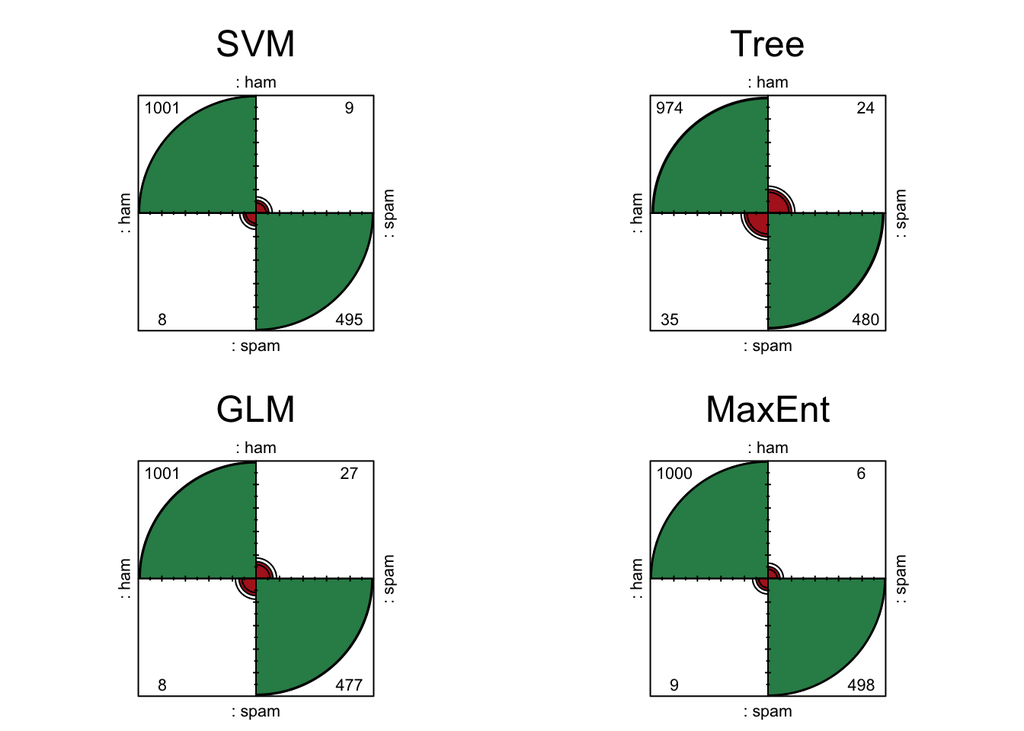

```r
par(mfrow=c(2,2))
fourfoldplot(svmconf$table, color = c("#B22222", "#2E8B57"), main="SVM")
fourfoldplot(treeconf$table, color = c("#B22222", "#2E8B57"), main="Tree")
fourfoldplot(glmconf$table, color = c("#B22222", "#2E8B57"), main="GLM")
fourfoldplot(maxentconf$table, color = c("#B22222", "#2E8B57"), main="MaxEnt")
```

## Comparison Table: F1 Score

```r
#setup df
eval <- data.frame(treeconf$byClass,
                   svmconf$byClass,
                   glmconf$byClass,
                   maxentconf$byClass)

eval <- data.frame(t(eval))

#calc FScore
precision <- eval$Pos.Pred.Value
recall <- eval$Sensitivity
eval$Fscore <- 2 * ((precision * recall) / (precision + recall))

# manipulate results DF
eval <- eval[,c(1:3, 9)]
row.names(eval) <- c("Tree", "SVM", "GLM", "MaxEnt")
eval <- eval[order(eval$Fscore, decreasing=TRUE),]

knitr::kable(eval)
```

|  | Sensitivity | Specificity | Pos.Pred.Value | Fscore |
| --- | --- | --- | --- | --- |
| MaxEnt | 0.9910803 | 0.9880952 | 0.9940358 | 0.9925558 |
| SVM | 0.9920714 | 0.9821429 | 0.9910891 | 0.9915800 |
| GLM | 0.9920714 | 0.9464286 | 0.9737354 | 0.9828179 |
| Tree | 0.9653122 | 0.9523810 | 0.9759519 | 0.9706029 |

# Conclusion

In summary, we ingested and cleaned our spam/ham data, then trained 4 different models using 75% of the data and tested on the withheld 25%. Our results were uniformly excellent, and we compared the models by using a confusion matrix and calculating the F1 score for binary classification using the precision and recall metrics. Note that in the confusionMatrix function in caret, these values precision = positive predictive value and recall = sensitivity.

As noted, all of the models performed very well. The Maximum Entropy and Support Vector Machines were the top performers with Fscores > 0.99. Combining models into an ensemble has the potential to improve performance even further.

The RTextTools package provides excellent one-stop shopping for document preparation and modelling, however the algorithm choices are limited and a bit too ‘black box’ for a noob learner like me. I look forward to learning more about the inner workings of individual modeling algorithms in future projects.

# References

- [Automated Data Collection with R, Chapter 10 - Munzert, Rubba, Meisner, Nyhuis](http://www.r-datacollection.com/)
- [RTextTools: A Supervised Learning Package for Text Classification - Jurka, Collingwood, Boydstun, Gorssman, Atteveldt](https://journal.r-project.org/archive/2013-1/collingwood-jurka-boydstun-etal.pdf)
- http://stackoverflow.com/questions/23891140/r-how-to-visualize-confusion-matrix-using-the-caret-package